# Global Monitoring Exploration: Displacement Data

Seth Caldwell

2022-07-27

This document quickly highlights the exploration done on displacement data for CERF global monitoring.

## Normalization

The first thing noticed about the data was that displacement events cover a wide range of days. Many cover only a single day, however, there are many events recording displacements across a much larger time period.

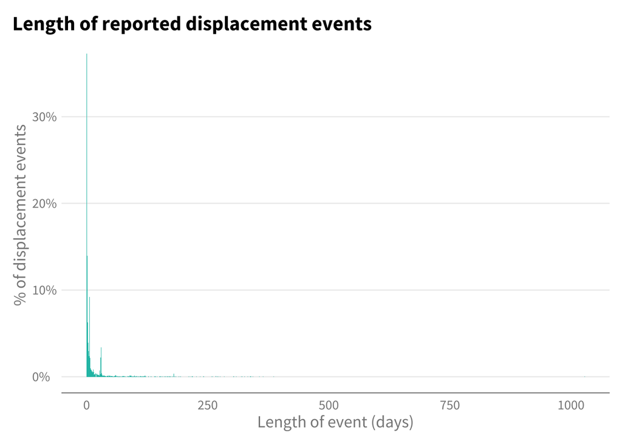

So, even though around one third of the events are on a single day, nearly two thirds last longer, with a wide range of values. The other issue is that the displacement events overlap across countries and multiple events can occur on the same date(s).

We need to standardize this in order to generate flags for outliers. Thus, all reported displacement events were normalized to daily events, with displacement numbers uniformly distributed across the days. Thus, 3,000 people displaced from July 1 to July 3 in a country would instead be reported as 1,000 people for each day.

Then, in each country, all displacement events on a specific day are normalized to generate a daily displacement figure. In the end, we have a daily time series for each country. This can then be used to generate flags for outliers or when we want to alert CERF.

## Flagging

The general idea behind the flagging here was that there might not be a single “outlier” that CERF would want to be alerted to. There might be long term displacement crises that do not see particularly high values, but has very high displacement across months or years. High daily displacement in one country may not be particularly high elsewhere. New displacement after a period of time without any might be important to flag, even if it isn’t necessarily when action needs to be taken if the displacement is small in size.

Thus, the following flags were calculated for exploration, and they are certainly not comprehensive of everything that could be tried.

### Country-level time series outliers

- Daily displacement that is in the 95th percentile for a country
- Weekly displacement that is in the 95th percentile for a country
- Monthly displacement that is in the 95th percentile for a country
- Quarterly displacement that is in the 95th percentile for a country
- Yearly displacement that is in the 95th percentile for a country
- Time series outliers calculated based on trend calculation (forecast package)

### Global time series outliers

- Daily displacement that is in the 95th percentile globally
- Weekly displacement that is in the 95th percentile globally
- Monthly displacement that is in the 95th percentile globally
- Quarterly displacement that is in the 95th percentile globally
- Yearly displacement that is in the 95th percentile globally

### Set thresholds

Set thresholds can also be used, simply aligning a clean and standard number that if above, flagging is done. The original numbers tested were generated by finding clean, whole numbers that were not as high as the 95th percentile of the global dataset, so that flagging would be more sensitive than the global time series above. These could be adjusted based on normative ideas on when action should be taken, analysis on when CERF has previously acted, or based on more detailed analysis of the available displacement data.

- Daily displacement over 5,000 persons (95th percentile is 10,948)
- Weekly displacement over 20,000 persons (95th percentile is 28,863)
- Monthly displacement over 100,000 persons (95th percentile is 120,648)
- Quarterly displacement over 250,000 persons (95th percentile is 311,688.4)
- Yearly displacement over 500,000 persons (95th percentile is 999,465)

### Flagging put together

Overall, putting the flags together, we can get a sense of when we might want to be paying attention to a country. Looking at the first displacement in a year, the the country-level percentile flags, and set thresholds together on a set of example countries, we see the following.

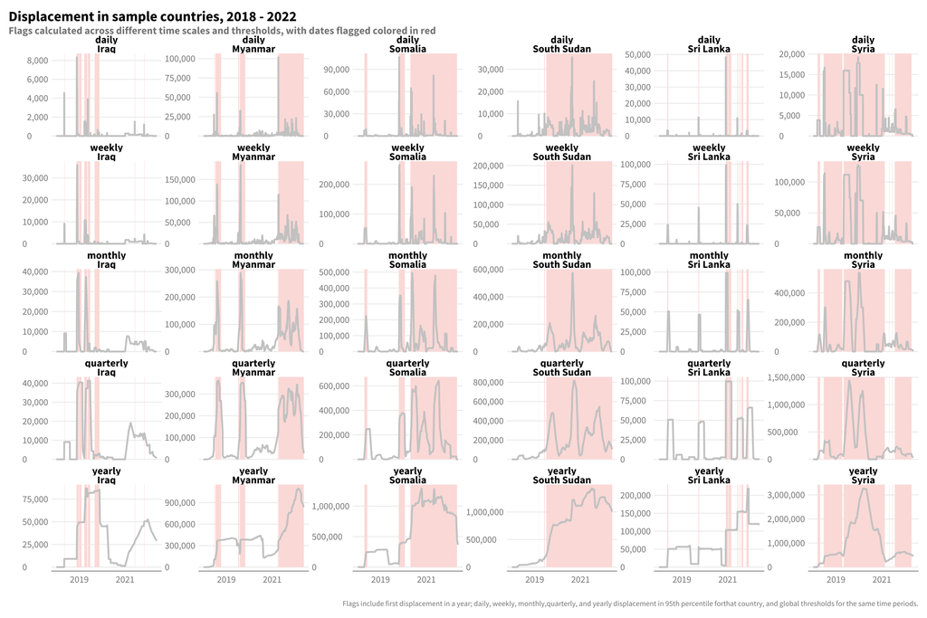

We can look at individual ones to see what is driving this, and plots for each have been saved to the Global Monitoring folder. However, the argument here is simply that allowing all flags to operate may be an easier and cleaner way to create flags that then allow additional investigation by desk officers and contextual experts to determine what actions should or should not be taken.